# Loan Exploration by Nikos Tavoularis

This report explores a loan dataset that comes from [Prosper](https://www.prosper.com/) which is a marketplace lending platform. More specifically, [Prosper Marketplace](https://en.wikipedia.org/wiki/Prosper_Marketplace) is America’s first peer-to-peer lending marketplace, with over $7 billion in funded loans. Borrowers request personal loans on Prosper and investors (individual or institutional) can fund them. Investors can consider borrowers’ credit scores, ratings, and histories and the category of the loan. Prosper handles the servicing of the loan and collects and distributes borrower payments and interest back to the loan investors.

The data set contains almost 114,000 loans and 81 variables, including loan amount, borrower rate (or interest rate), current loan status, borrower income, borrower employment status, borrower credit history, the latest payment information among others. A full list of the variables can be found [here](https://docs.google.com/spreadsheets/d/1gDyi_L4UvIrLTEC6Wri5nbaMmkGmLQBk-Yx3z0XDEtI/edit#gid=0).

# Univariate Plots Section

Let’s firstly check the distribution of loan origination through the years.

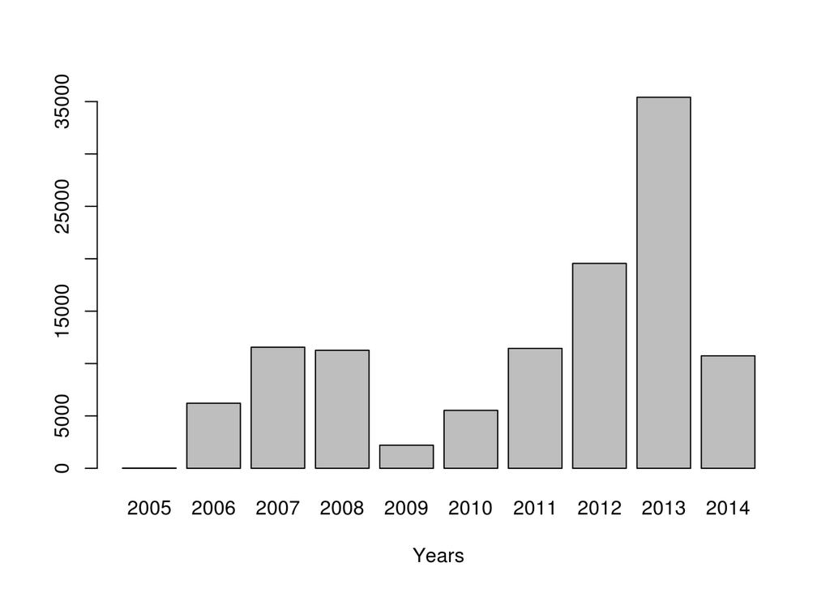

```
##
##  2005  2006  2007  2008  2009  2010  2011  2012  2013  2014
##    23  6213 11557 11263  2206  5530 11442 19556 35413 10734
```

```
## [1] "2005-11-09" "2014-03-10"
```

```
## [1] 113937
```

The dataset contains 113.937 loans from November 2005 till March 2014. Most loans were originated in 2013. If we zoom in a little bit in our diagram…

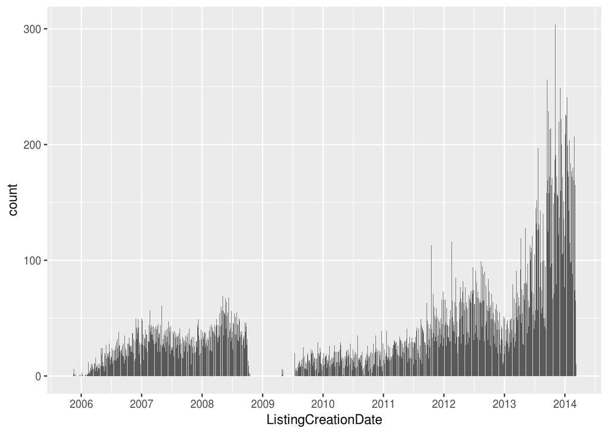

…we can notice that there is a gap in the data in late 2008. There is a clear explanation about this issue. In the wikipedia PROSPER [article](https://en.wikipedia.org/wiki/Prosper_Marketplace) we are informed that “the SEC imposed a cease and desist order on Prosper” from the end of November 2008 till July 2009.

But what is the status of each loan in the dataset?

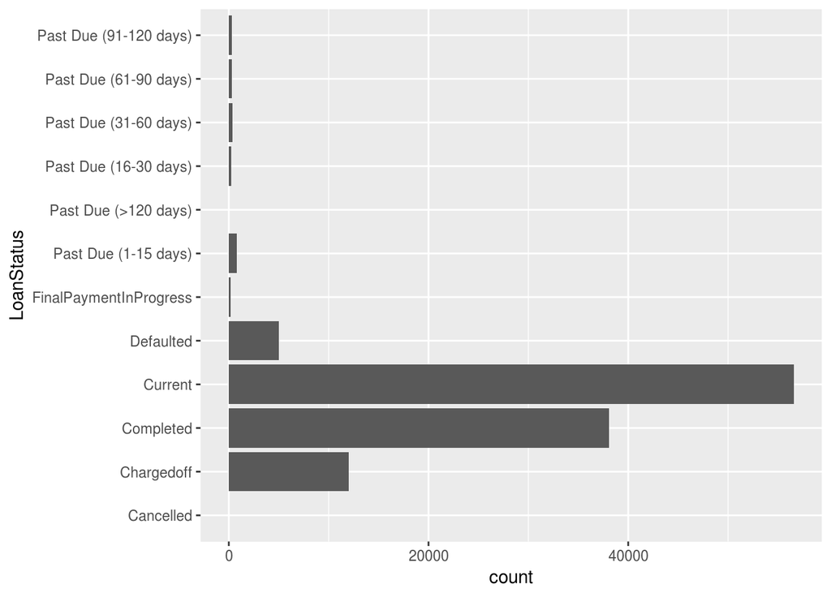

```
##
##              Cancelled             Chargedoff              Completed
##                    0.0                   10.5                   33.4
##                Current              Defaulted FinalPaymentInProgress
##                   49.7                    4.4                    0.2
##   Past Due (1-15 days)   Past Due (>120 days)  Past Due (16-30 days)
##                    0.7                    0.0                    0.2
##  Past Due (31-60 days)  Past Due (61-90 days) Past Due (91-120 days)
##                    0.3                    0.3                    0.3
```

Almost half the loans are still in progress and 1/3 of loans are completed.

Let’s examine the credit rating of loans when they went live. To measure the credit rating we can use the Credit Grade variable. This variable is populated only for listings before 2009 (before the SEC cease). The [Credit Grade](https://www.prosper.com/Downloads/Services/Documentation/ProsperAPI_Objects_Details.html) is expressed in an alphabetical grade scale where AA is the best possible credit rating for a loan taker and HR is the worst possible rating (NC means No Credit).

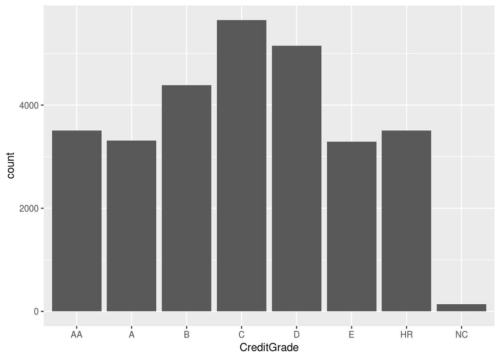

```
##
##     A    AA     B     C     D     E    HR    NC  <NA>
##  3315  3509  4389  5649  5153  3289  3508   141 84984
```

Most loan takers before 2009 had a credit rating of C and D. Note that we removed NA’s from the graph because essenially NA’s in the Credit Grade variable correspond to loan takers after July 2009.

As for the loan takers after July 2009 we are going to use the ProsperRating (Alpha) variable. The ProsperRating is a proprieatary system developped by PROSPER after the SEC cease that [“allows potential investors to easily consider a loan application’s level of risk because the rating represents an estimated average annualized loss rate range to the investor.”](https://www.prosper.com/plp/invest/prosper-ratings/) So it seems reasonable to use it for measuring the credit risk of each loan taker as it fulfils the same role as the Credit Grade variable.

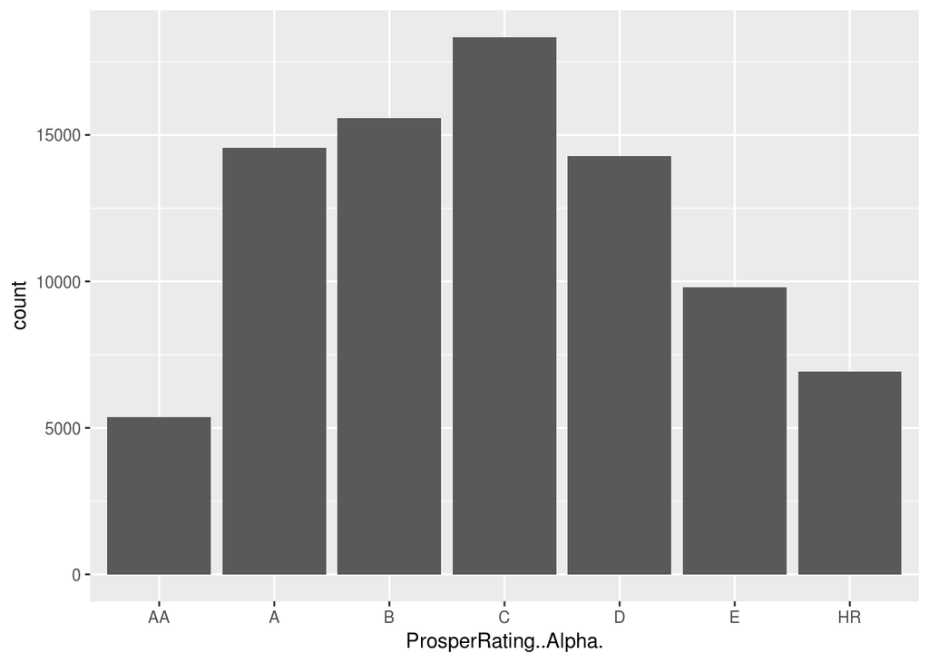

```
##
##     A    AA     B     C     D     E    HR  <NA>
## 14551  5372 15581 18345 14274  9795  6935 29084
```

The Prosper Rating follows a similar grading scale as the Credit Rating.

Most loan takers after 2009 had a credit rating of B and C and few loan takers had a credit rating of AA.

What is the most common term of a PROSPER loan?

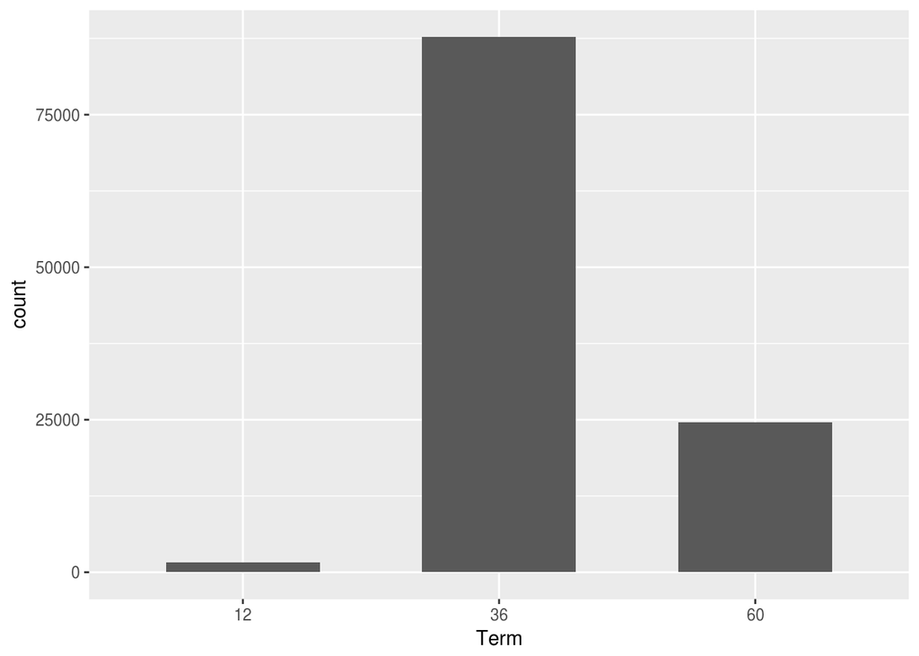

```
##
##   12   36   60
##  1.4 77.0 21.5
```

77% of all loans has a 36 months term in the PROSPER marketplace.

Now lets check the distribution of loan amounts:

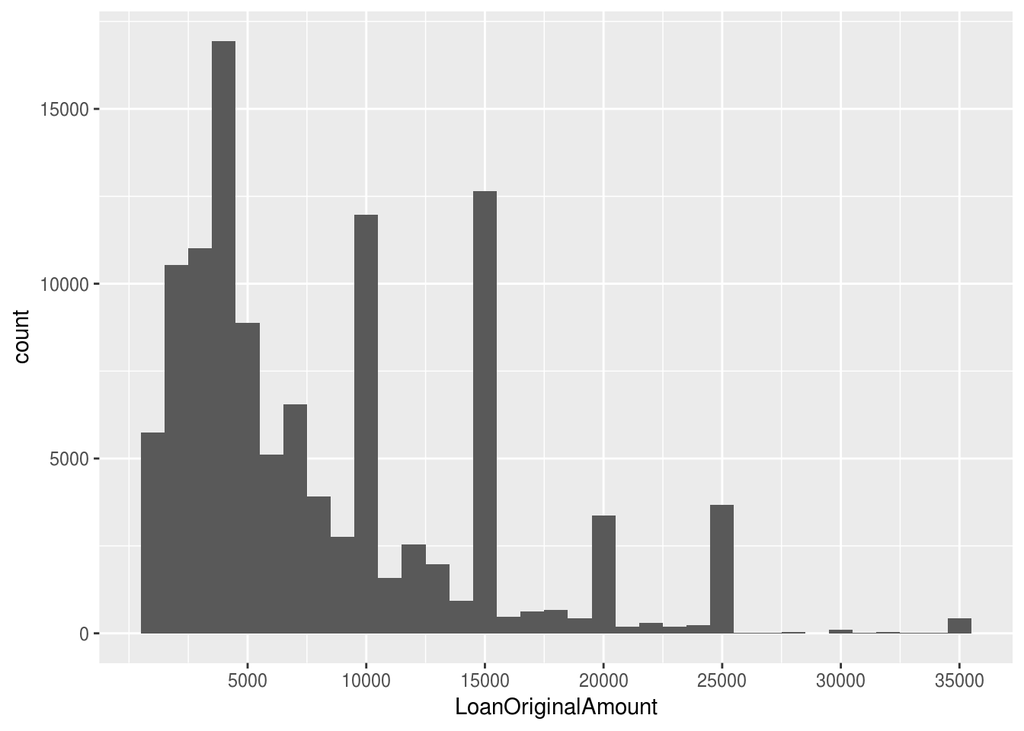

```
##    Min. 1st Qu.  Median    Mean 3rd Qu.    Max.
##    1000    4000    6500    8337   12000   35000
```

```
##
##       [0,5e+03]   (5e+03,1e+04] (1e+04,1.5e+04] (1.5e+04,2e+04]
##            45.5            27.3            17.6             5.0
## (2e+04,2.5e+04] (2.5e+04,3e+04] (3e+04,3.5e+04]
##             4.0             0.2             0.4
```

```
##
##  4000 15000 10000  5000  2000  3000 25000 20000  1000  2500
## 14333 12407 11106  6990  6067  5749  3630  3291  3206  2992
```

```
## [1] 949894347
```

But what is the reason specified by loan takers for asking the loan?

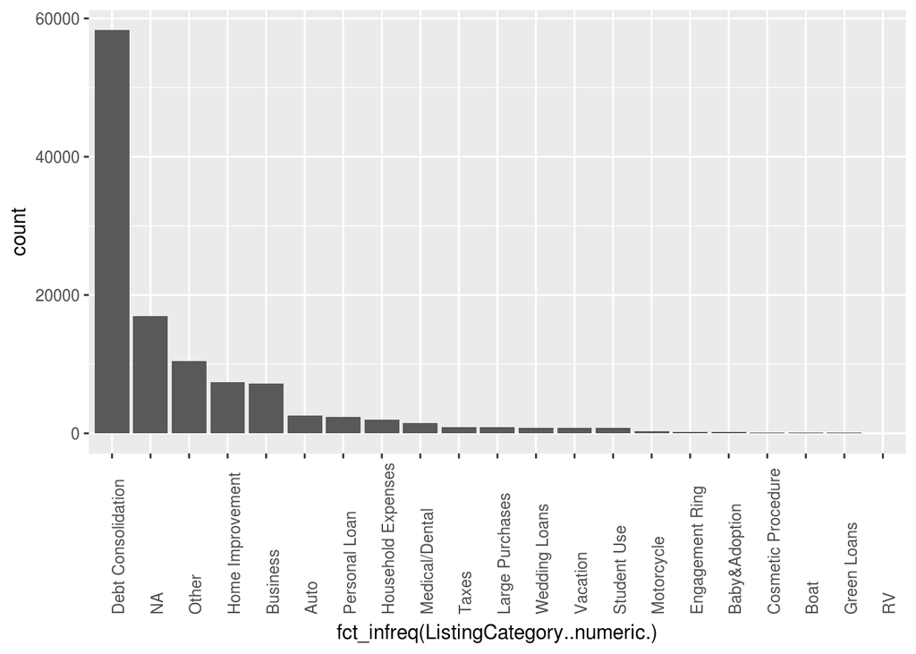

```
##                 NA Debt Consolidation   Home Improvement
##              16965              58308               7433
##           Business      Personal Loan        Student Use
##               7189               2395                756
##               Auto              Other      Baby&Adoption
##               2572              10494                199
##               Boat Cosmetic Procedure    Engagement Ring
##                 85                 91                217
##        Green Loans Household Expenses    Large Purchases
##                 59               1996                876
##     Medical/Dental         Motorcycle                 RV
##               1522                304                 52
##              Taxes           Vacation      Wedding Loans
##                885                768                771
```

Most loan takers use the PROSPER platform for debt [consolidation](http://www.investopedia.com/terms/d/debtconsolidation.asp). Many people don’t specify the category of their loan (NA option). The third most popular listing selection by loan takers is “other”. “Home improvement” and “Business” come in fourth and fifth place.

What is the occupation of loan takers?

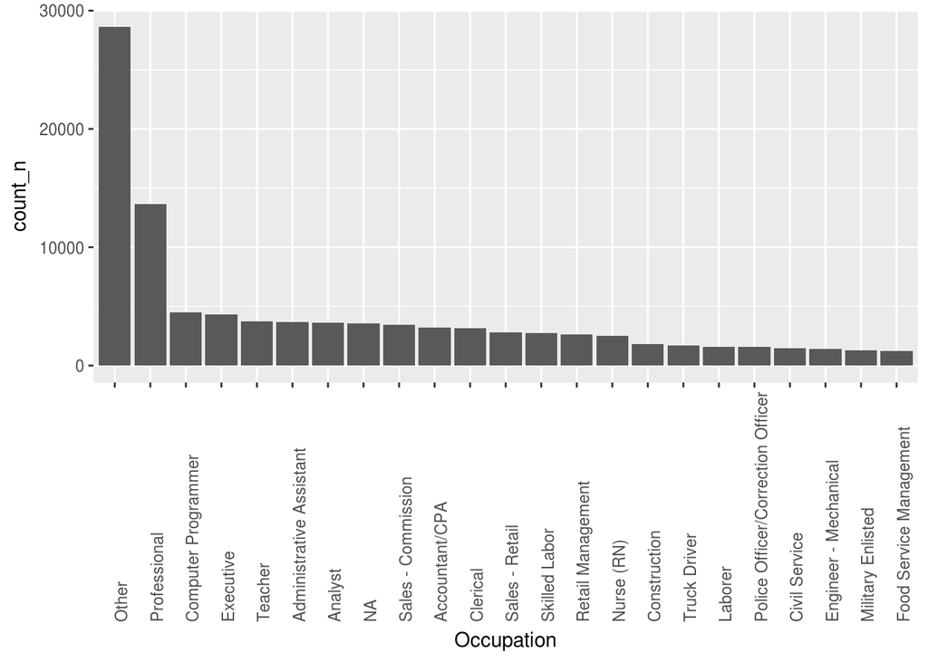

```
## [1] 68
```

```
##
##                    Other             Professional      Computer Programmer
##                     25.1                     12.0                      3.9
##                Executive                  Teacher Administrative Assistant
##                      3.8                      3.3                      3.2
##                  Analyst       Sales - Commission           Accountant/CPA
##                      3.2                      3.0                      2.8
##                 Clerical
##                      2.8
```

```
## [1] 86.2
```

There are 68 different occupations selected in the dataset by the loan takers. Most popular categories by a large margin are “Other” and “Professional” which are not terribly useful for our analysis since they are too generic. Computer Programmer is the third most common selection as can be seen from the graph, Executive came in the fourth place and Teacher in the fifth. 86.2% of answers about Occupation fall in the top 1/3 of answers. The barplot of top 1/3 of anwers is depicted in the graph above.

The income range of loan takers could probably be a useful variable to explore:

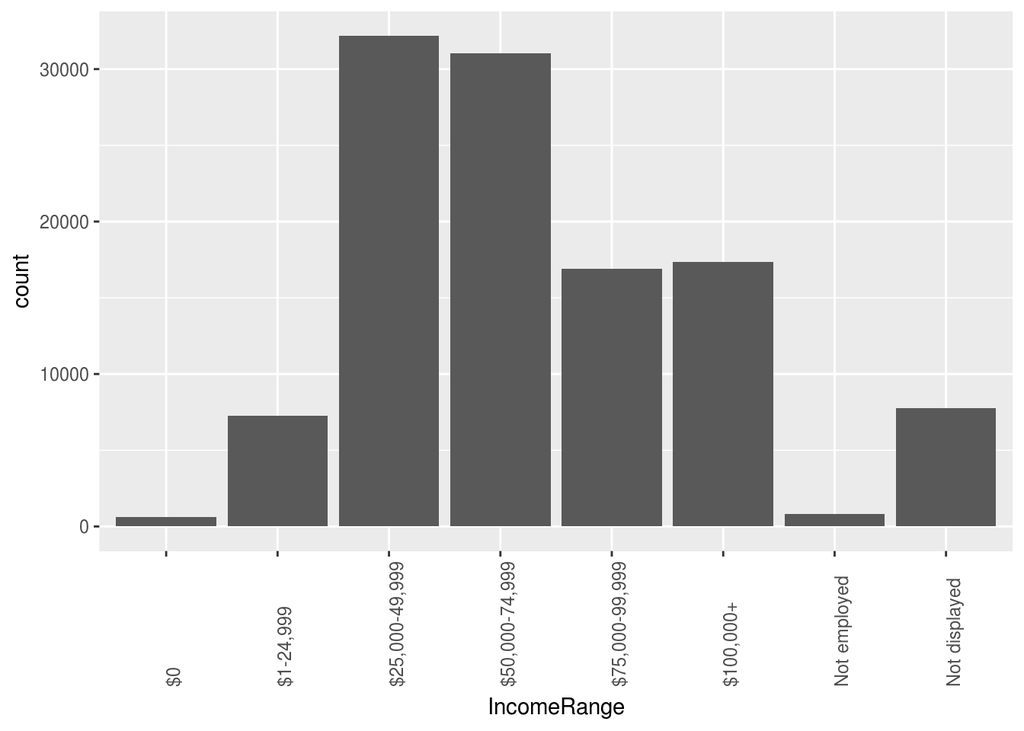

```
##      IncomeRange count_n perc
## 1 $25,000-49,999   32192 28.3
## 2 $50,000-74,999   31050 27.3
## 3      $100,000+   17337 15.2
## 4 $75,000-99,999   16916 14.8
## 5  Not displayed    7741  6.8
## 6      $1-24,999    7274  6.4
## 7   Not employed     806  0.7
## 8             $0     621  0.5
```

Most people in the dataset have an income that ranges between $25.000 and $75.000. According to this wikipedia [article](https://en.wikipedia.org/wiki/Personal_income_in_the_United_States) only the top 9.15% of U.S population had a personal income larger than $100.000 in 2016. So, it is somehow strange that the third most common income range category for loan takers is high income people (+$100.000).

To conclude this section we are going to plot three more variables that may be useful in the analysis that will follow: Recommendations, InvestmentFromFriendsCount and Investors.

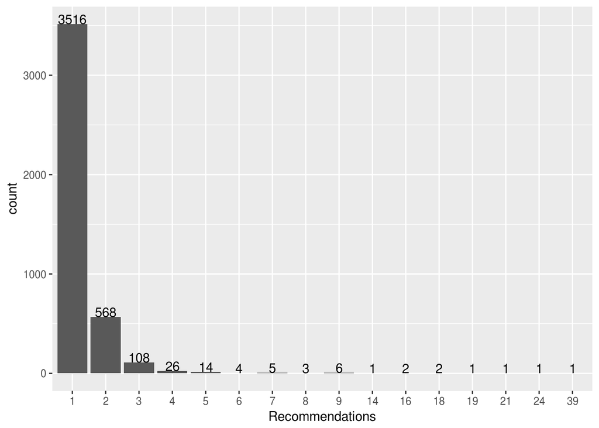

```
## [1] 96.3
```

```
## [1] 3.7
```

```
##
##    0    1    2    3    4    5    6    7    8    9   14   16   18   19   21
##  0.0 82.6 13.3  2.5  0.6  0.3  0.1  0.1  0.1  0.1  0.0  0.0  0.0  0.0  0.0
##   24   39
##  0.0  0.0
```

Only 3.7% of loan takers had a recommendation when they posted their listing. From those people the large majority (3.516 or 82.6%) had only one recommendation.

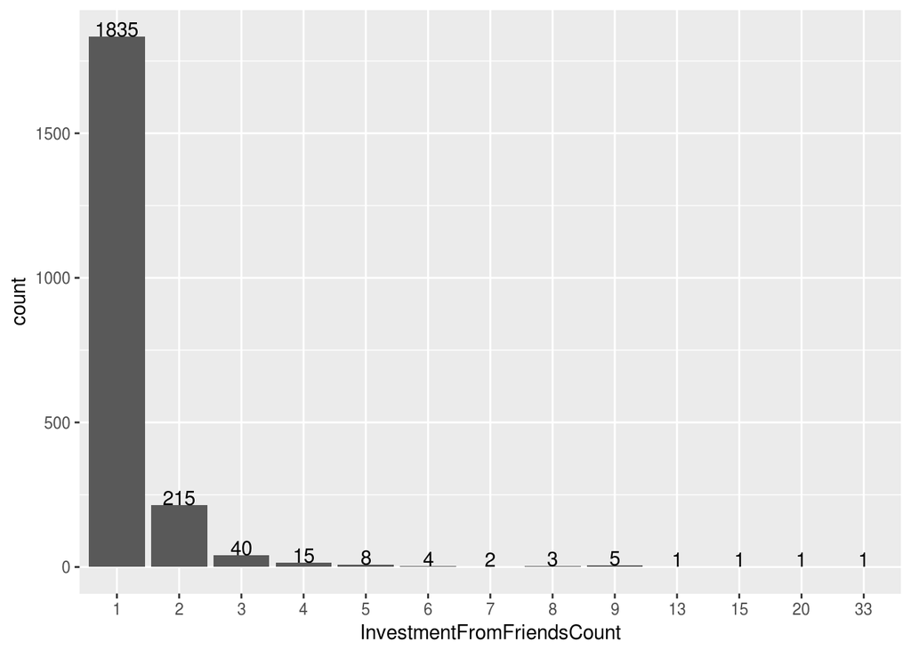

```
## [1] 98.1
```

```
## [1] 1.9
```

```
##
##    0    1    2    3    4    5    6    7    8    9   13   15   20   33
##  0.0 86.1 10.1  1.9  0.7  0.4  0.2  0.1  0.1  0.2  0.0  0.0  0.0  0.0
```

Less than 2% of loan takers had friends investing on their loan. The most common friend count was one person (86.1%).

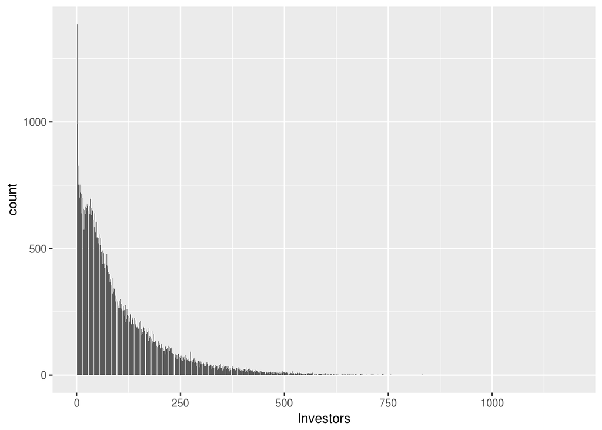

```
##    Min. 1st Qu.  Median    Mean 3rd Qu.    Max.
##    1.00    2.00   44.00   80.48  115.00 1189.00
```

```
##
##     1     2     3     4     5     8    10     6     9    11
## 24.41  1.22  0.87  0.73  0.66  0.66  0.64  0.63  0.63  0.63
```

```
##
##           [0,100]         (100,200]         (200,300]         (300,400]
##             81470             19372              7790              3119
##         (400,500]         (500,600]         (600,700]         (700,800]
##              1374               545               181                53
##         (800,900]       (900,1e+03]   (1e+03,1.1e+03] (1.1e+03,1.2e+03]
##                26                 3                 3                 1
```

```
##
##           [0,100]         (100,200]         (200,300]         (300,400]
##            71.504            17.002             6.837             2.737
##         (400,500]         (500,600]         (600,700]         (700,800]
##             1.206             0.478             0.159             0.047
##         (800,900]       (900,1e+03]   (1e+03,1.1e+03] (1.1e+03,1.2e+03]
##             0.023             0.003             0.003             0.001
```

Almost 1/4 of loans were funded by a single investor. The distribution of investor number per loan is heavily skewed to the right (note that 1 investor per loan category is omitted, otherwise other categories wouldn’t be visible). 71.5% of loans were funded by less than 100 investors and only 4 loans had more than 1000 investors.

# Univariate Analysis

### What is the structure of your dataset?

As it was mentioned in the beginning of this project the data set contains 113.937 loans and 81 variables, including loan amount, borrower rate (or interest rate), current loan status, borrower income, borrower employment status, borrower credit history, the latest payment information among others.

### What is/are the main feature(s) of interest in your dataset?

It is interesting to explore which variables can help potential investors avoid loan takers that most likely will default on their loan. Also, I am curious to check if the behavior and characterics of loan takers changed after the financial crisis of 2008 in the PROSPER platform.

### What other features in the dataset do you think will help support your investigation into your feature(s) of interest?

It is not possible to explore all the variables in this dataset due to time constraints, so I chose 12 supporting variables that were presented in the univariate plots section in order to conduct my anlysis against the features of interest, namely:

- ListingCreationDate
- LoanStatus
- CreditGrade
- ProsperRating..Alpha.
- Term
- LoanOriginalAmount
- ListingCategory..numeric
- Occupation
- IncomeRange
- Recommendations
- InvestmentFromFriendsCount
- Investors

### Did you create any new variables from existing variables in the dataset?

I created four new variables in the bivariate plots section. The first one classifies loans as defaulted and non-defaulted. The second one groups listings by year of initiation. The third one combines the CreditGrade and the ProsperRating…Alpha. variables into a single variable. And the last one splits the Investors variable in ten categories.

In the multivariate plots section I created a variable that divides the dataset in two time periods. The first period contains listings up until 2008. The second one covers listings from 2009 and onwards.

### Of the features you investigated, were there any unusual distributions? Did you perform any operations on the data to tidy, adjust, or change the form of the data? If so, why did you do this?

The LoanOriginalAmount distibution is heavily skewed to the right, which is not what I expected. I originally thought that loan amounts would be centered around $5.000 - $10.0000 not below $5.000 as they actually do.

I changed the data type of the following variables:

- ListingCategory..numeric
- Reccomendations
- InvestmentFromFriendsCount

from numeric to factor to better visualize their distribution.

# Bivariate Plots Section

We will create a new variable that classifies loans as defaulted and non defaulted. We are going to use the LoanStatus variable to achive that. As a reminder the LoanStatus variable with its loan type counts is depicted below.

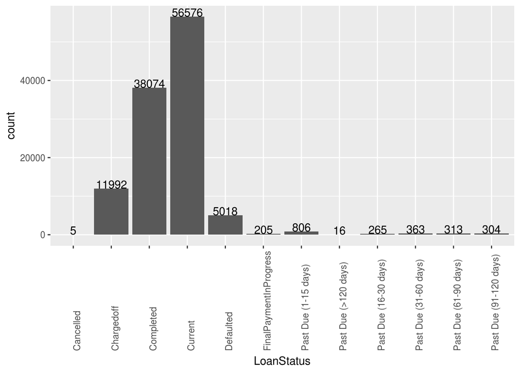

```
## [1] 55084
```

We will name the new variable as Defaulted and it will take only two values: either “Yes”" or “No”. We will include to the “Yes” category the Defaulted and [Chargedoff](https://www.investopedia.com/terms/c/chargeoff.asp) loans from the LoanStatus variable and to the “No” category the Completed loans of the same variable. We will omit the other categories from the LoanStatus variable because we don’t know their outcome yet (if the loan will default or not).

As a consequence we will drop the data for all loans that don’t belong to the aforementioned categories. The total number of loans that we are going to work with is 55.084. Let’s have a first look at the percentage of defaulted loans in the newly created dataset:

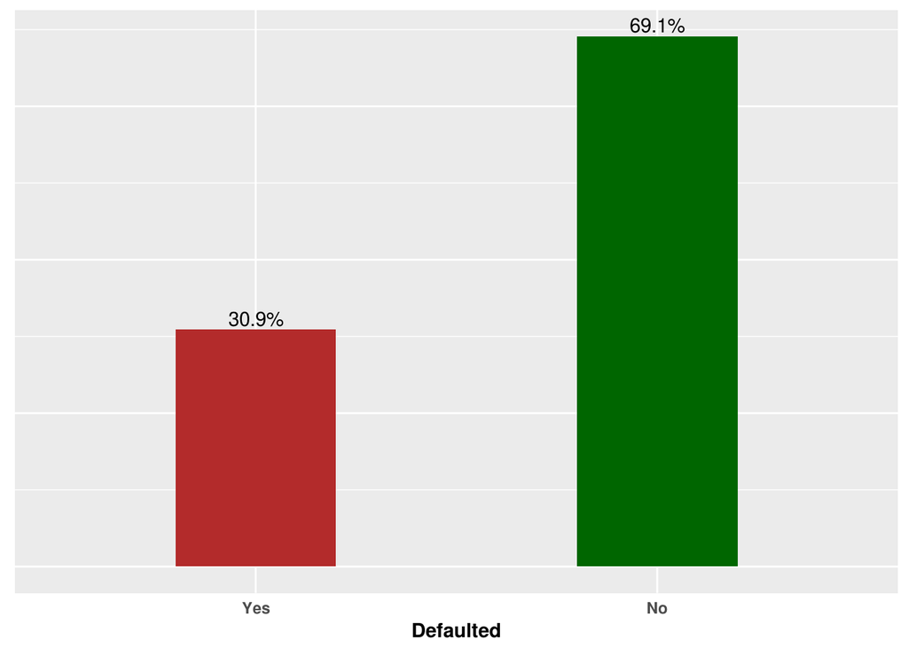

3 out of 10 loans defaulted in the selected dataset. This is a really high percentage of defaulted loans. Lets plot the selected examined variables in the univariate plots section against the “Yes” and “No” categories.

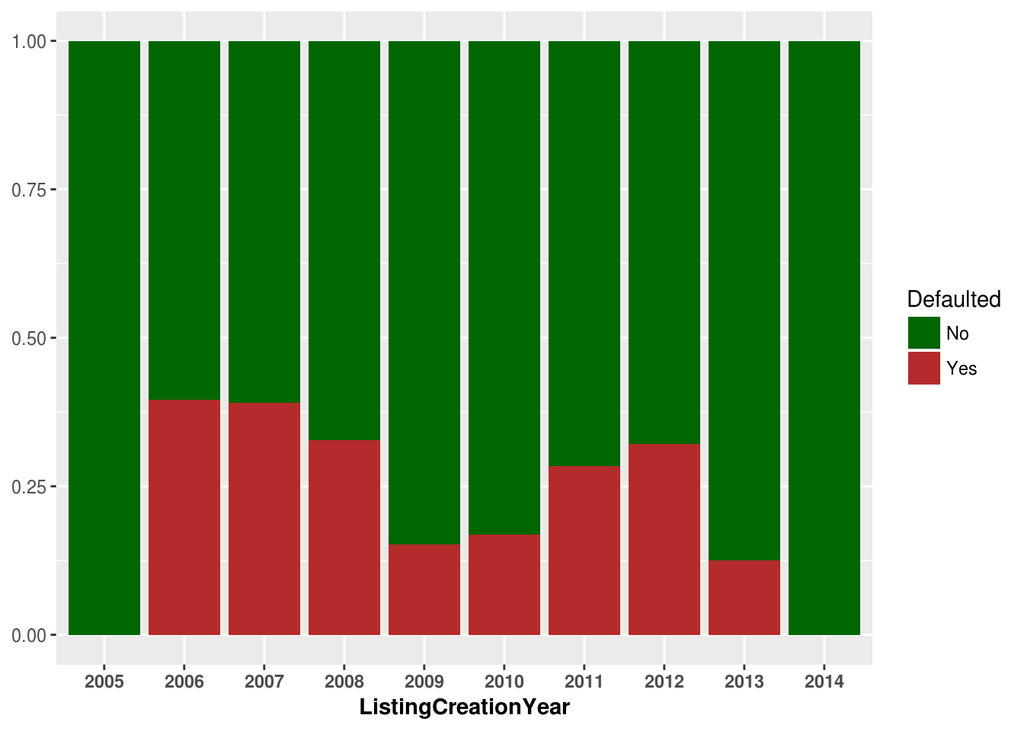

```
##
##  2005  2006  2007  2008  2009  2010  2011  2012  2013  2014
##    23  6209 11557 11262  2206  5489  7700  8032  2544    62
```

It seems that loans that were initiated in 2006 and 2007 had a higher chance of default than loans in other years. As a note keep in mind that for 2005 and 2014 there are few loan listings in the dataset (23 and 62 respectively).

Now lets check the credit risk of loan takers against the Defaulted variable. We will combine the CreditGrade and the ProsperRating…Alpha. variables in one new variable called Credit_Risk. As a reminder CreditGrade was applicable for loans for the pre-2009 period and ProsperRating…Alpha. for loans after July 2009. So combining them let us analyse the credit risk for the whole period covered by our dataset.

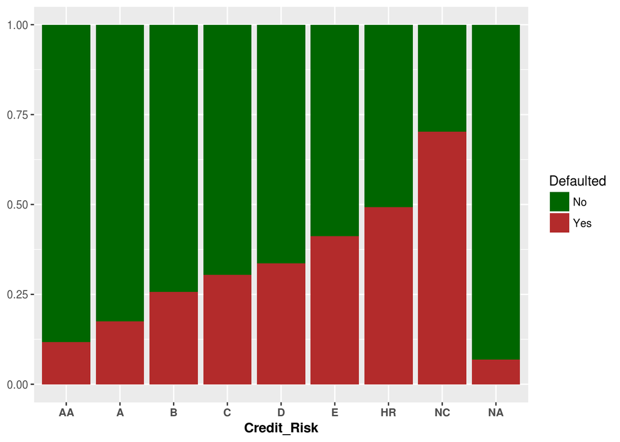

Ok so it is pretty clear that the lower the Credit Risk rating the higher the probability of default of a loan taker.

Is loan duration related to defaults?

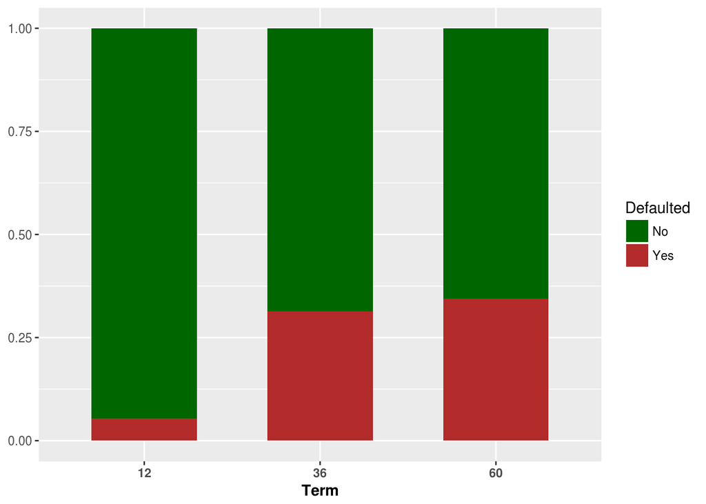

```
##    Cell Contents
## |-------------------------|
## |                   Count |
## |          Column Percent |
## |-------------------------|
##
## ========================================================
##                            PLD_def_or_no$Term
## PLD_def_or_no$Defaulted       12      36      60   Total
## --------------------------------------------------------
## No                         1450   34200    2424   38074
##                            94.6%   68.6%   65.6%
## --------------------------------------------------------
## Yes                          82   15656    1272   17010
##                             5.4%   31.4%   34.4%
## --------------------------------------------------------
## Total                      1532   49856    3696   55084
##                             2.8%   90.5%    6.7%
## ========================================================
```

We can see that 12 months listings have a significant lower default rate than 36 and 60 months listings. Keep in mind that 12 months loans represented only 2.8% of loans in the dataset.

Let’s see if there is a relation between the loan amount and the default rate.

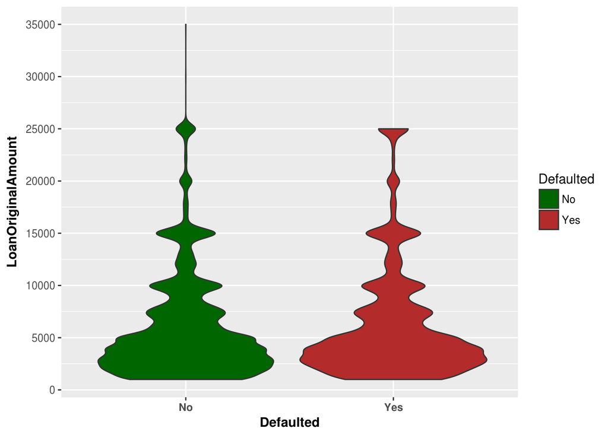

```
## # A tibble: 2 x 5
##   Defaulted median     mean standard_dev   IQR
##      <fctr>  <dbl>    <dbl>        <dbl> <dbl>
## 1        No   4500 6189.093     5087.737  5450
## 2       Yes   4500 6424.842     5494.314  5100
```

It’s not likely that loan amount plays any significant role in the likelihood of default according to the above graph and summary statistics. Both violin plots looks pretty similar and their distribution is mainly concentrated below $5.000. The only difference that we can easily spot is that there are no loans above $25.000 that had defaulted.

Let’s visualize which listing category had the biggest percentage of default:

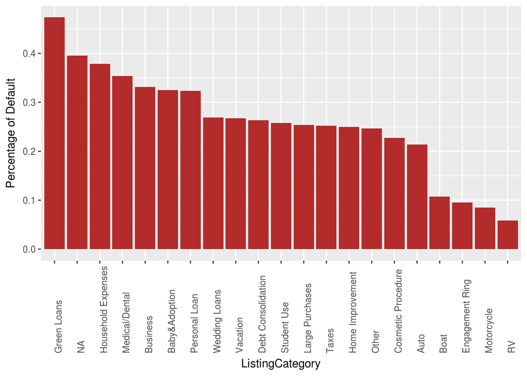

[Green loans](https://www.prosper.com/plp/loans/loan-types/green-loans/), loans that have undifined loan category and loans for Household Expenses had the higher rate of default.

Following the same procedure as above for occupation categories produces the following three graphs:

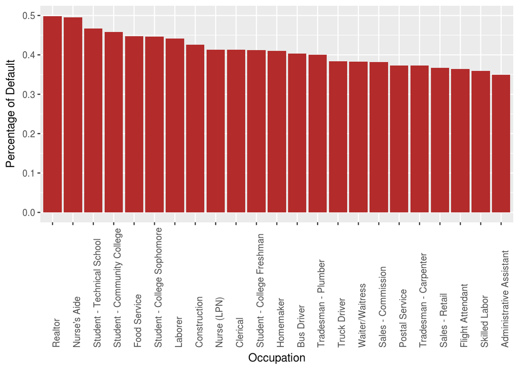

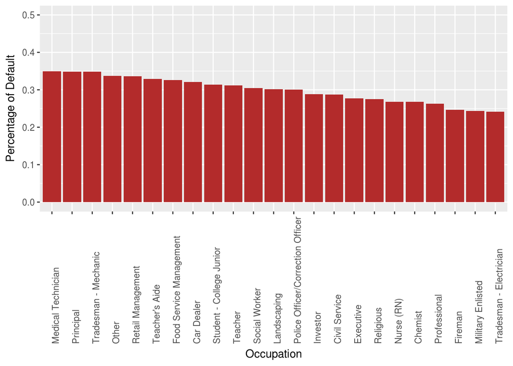

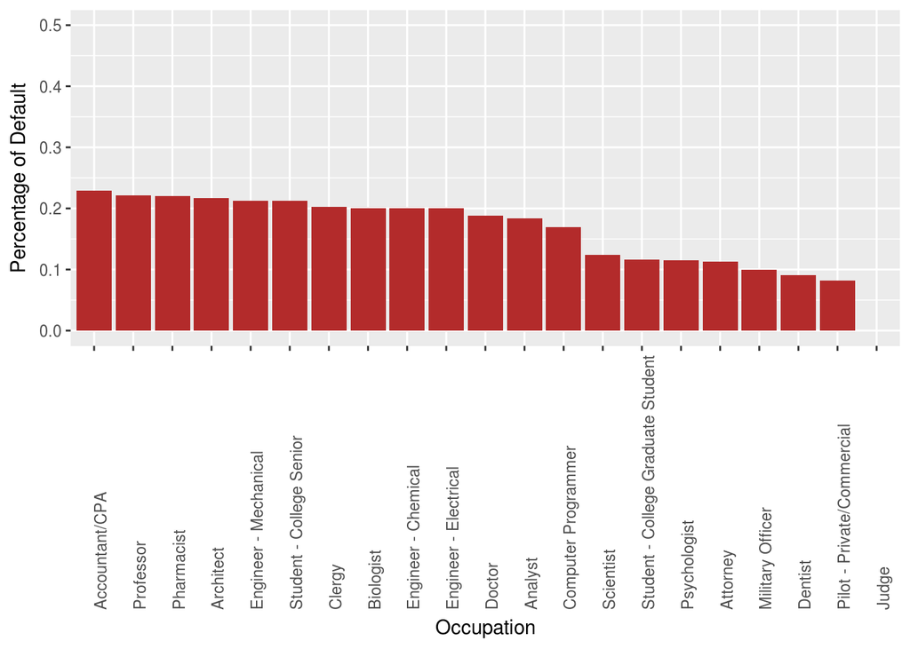

Realtors and Nurse’s Aides had almost a 50% probabibilty of defaulting on their loans! Technical and Community College students came in the third and fourth place with probabibility of default around the 45% mark. No Judge had ever defaulted (but there are only two in the dataset).

What about income range of loan takers?

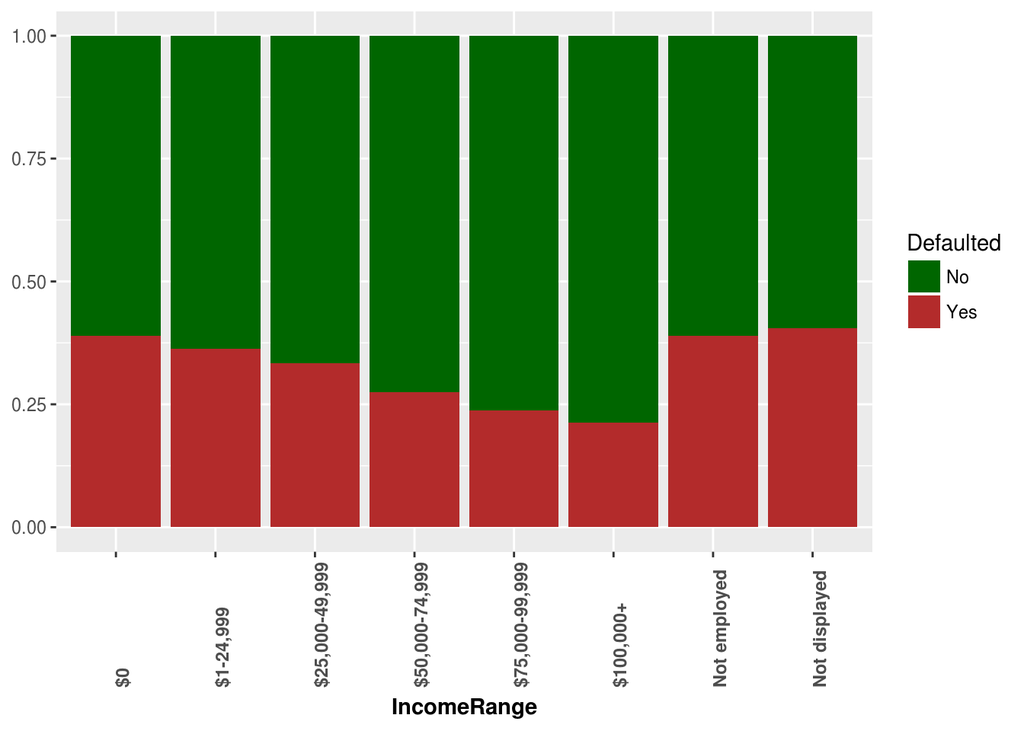

No surprises here. The higher the income the lower the probability of default (except for the $0 category, which we will explore it later on).

Checking if the number of recommendations the borrower had and the number of friends that made an investment in the loan at the time the listing was created are related somehow to the default ratio:

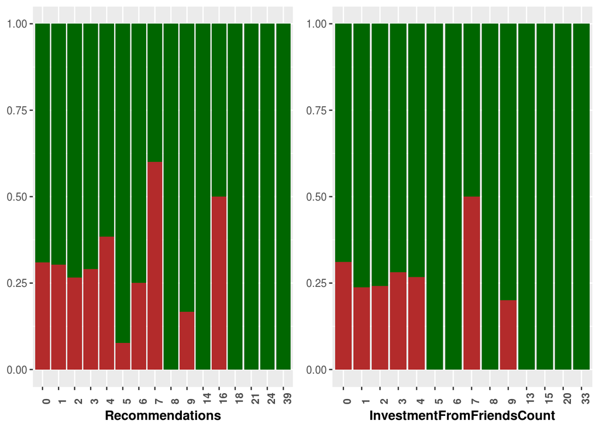

This is not what someone might expect. Logically larger number of recommendations or investment from friends should produce a lower rate of default. This is not the case in the above two graphs, but nevertheless we should not forget that there are few observations for counts above 2 in both graphs. So it’s seems prudent to not make any inference about those two variables.

So let’s check if the number of investors reveal any useful insights for the probability of default:

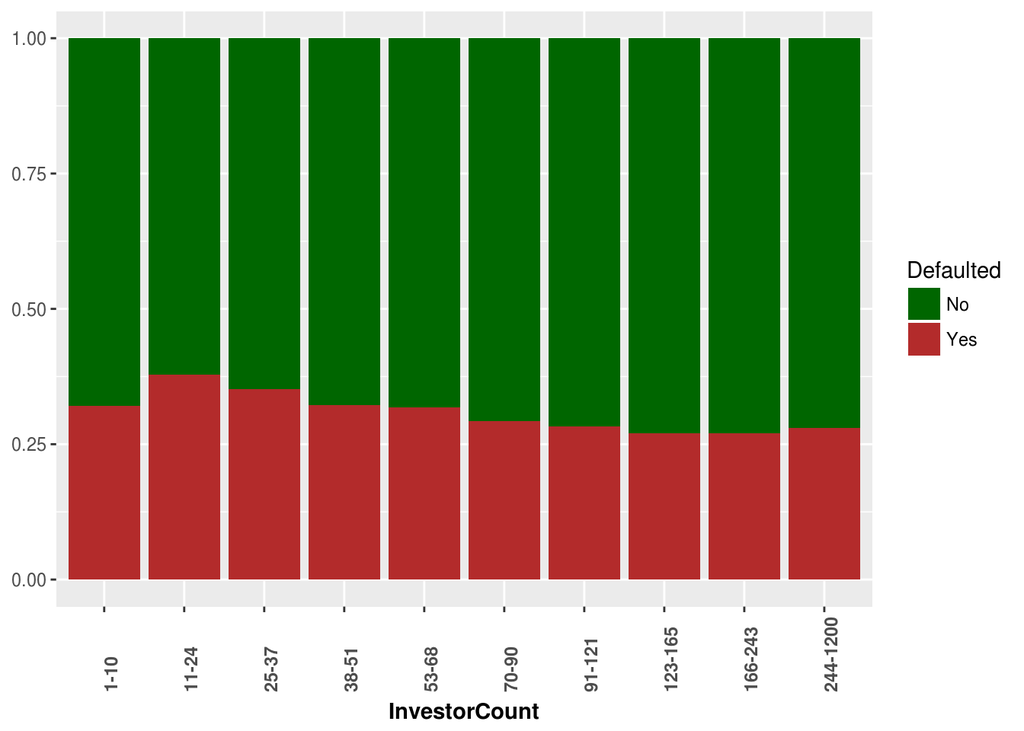

In the above chart we splitted the investor count data into approximately equal frequency bins to better visualize it. It seems that as the number of investors surpasses 25 the rate of default goes down. It increases again a little bit after 244 investors which seems quite odd.

Now it’s time to have a quick look at possible relationships between the supporting varibles of our analysis. Let’s see if Investors count is related to Income Range:

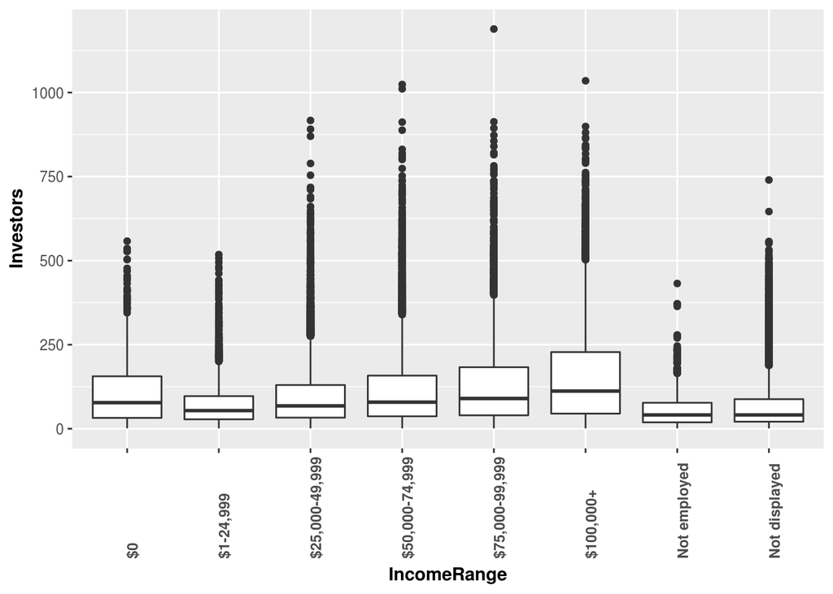

We can spot a trend here. The higher the Income Range of the loan taker the higher the number of people willing to invest in a loan, which of course makes sense. But clearly the $0 income range category seems like an outlier..

Is loan amount related to IncomeRange?

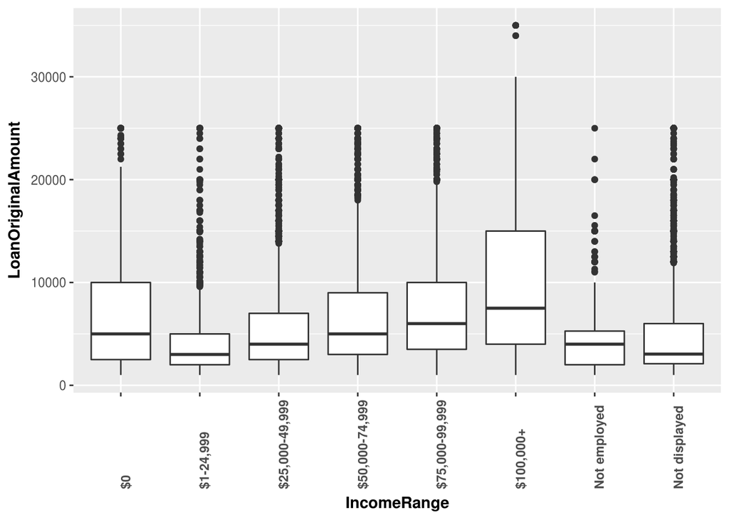

```
## # A tibble: 8 x 2
##      IncomeRange     mean
##           <fctr>    <dbl>
## 1      $100,000+ 9711.120
## 2 $75,000-99,999 7719.072
## 3             $0 7421.954
## 4 $50,000-74,999 6564.272
## 5 $25,000-49,999 5285.641
## 6  Not displayed 5171.352
## 7   Not employed 4579.519
## 8      $1-24,999 4164.764
```

Αs the Income Range gets higher so does the loan amount. But we can see that people with $0 income managed to borrow higher amounts on average than people in the income range $1 to $74,999 which is totally unexpected. As a first guess we could think that the $0 category is mainly populated by students that use PROSPER to get student loans. Let’s see if that’s the case:

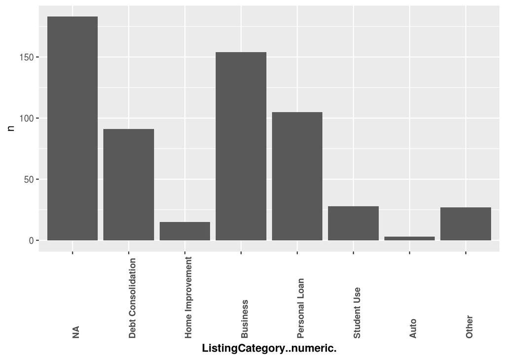

Clearly that’s not the case. Let’s check the year of initiation of those loans:

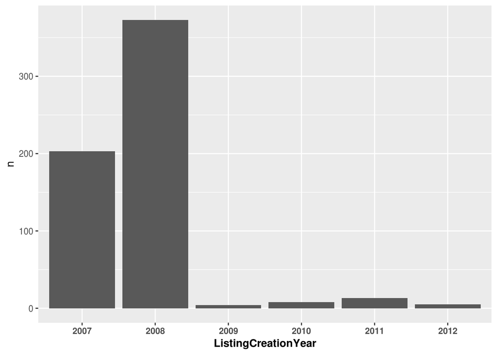

Almost all these loans where initiated in the first years of PROSPER operation. I believe that the Credit_Risk variable can help us a little bit more here. Let’s visualize the credit risk for the $0 and the $50,000-74,999:

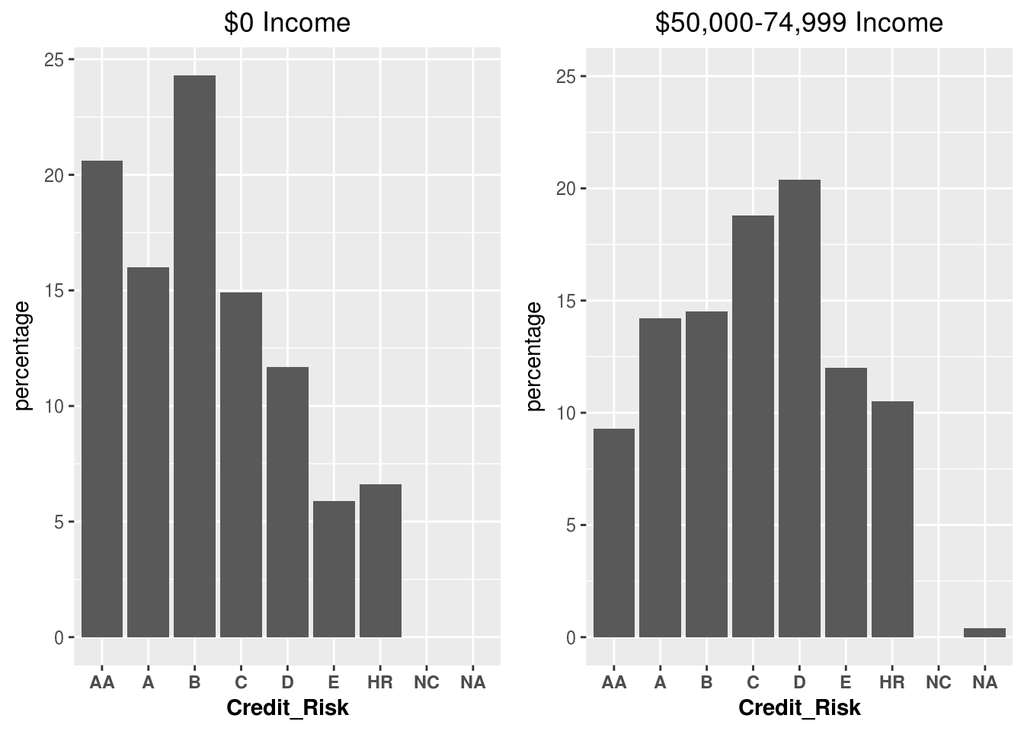

The top 3 credit risk ratings of loan takers with $0 income were AA, A and B! But loan takers with income of $50,000-74,999 had clearly worse ratings…Checking the number of loan takers in each loan category:

```
##
##             $0      $100,000+      $1-24,999 $25,000-49,999 $50,000-74,999
##            606           6064           4571          16343          12789
## $75,000-99,999  Not displayed   Not employed
##           6442           7737            532
```

The number of loan takers in the $0 income category is really low compared to the other income range categories. If we check again the listing category of these loans….

```
##   ListingCategory..numeric.   n perc
## 1                        NA 183 30.2
## 2                  Business 154 25.4
## 3             Personal Loan 105 17.3
## 4        Debt Consolidation  91 15.0
## 5               Student Use  28  4.6
## 6                     Other  27  4.5
## 7          Home Improvement  15  2.5
## 8                      Auto   3  0.5
```

…..we can see that the top two categories are loans that are listed as NA and Business loans. So I think these $0 income loans were initiated on behalf of small companies that needed some quick financing and this was probably allowed in the initial years of PROSPER operation. This probably explains the high ratings, the high mean amount per loan too and the high number of investors willing to invest on these loans. But this is just a hypothesis and we should take it with a grain of salt.

Finally to conclude this section let’s have a quick glance in the graph below that depicts the relation between the loan amount and the number of investors:

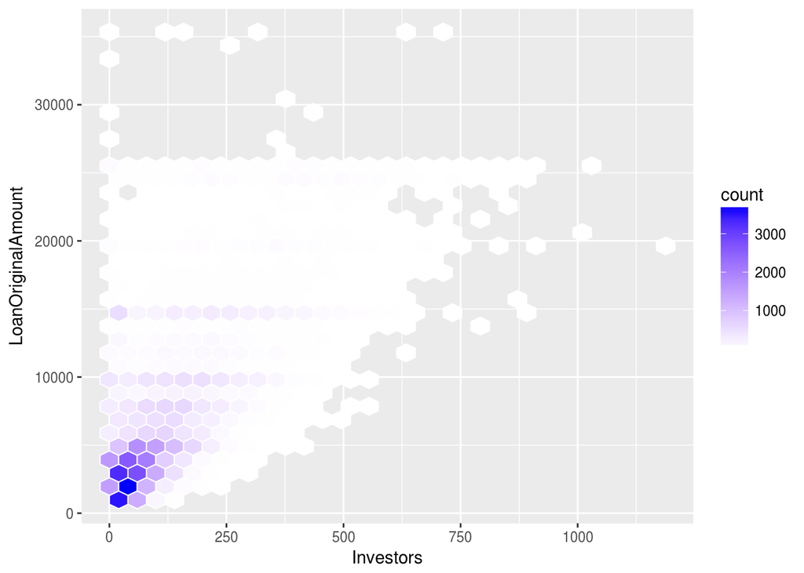

```
## [1] 0.68
```

It seems that there is a fairly positive relationship between the two variables. Their correlation coefficient is 0.68.

# Bivariate Analysis

### Talk about some of the relationships you observed in this part of the investigation. How did the feature(s) of interest vary with other features in the dataset?

I explored the relationships of the Defaulted variable, which is one of the features of interest, with 10 other variables. I found some non-surprising results:

- The higher the credit risk of a loan the higher the chance that will default.
- Longer term loans tend to default more often than shorter ones.
- The higher the income of the loan taker the lower the probability of defaulting in its loan.
- More investors in a loan usually means lower rate of default.

### Did you observe any interesting relationships between the other features (not the main feature(s) of interest)?

- The higher the income range of a loan taker, more people are willing to invest in his/her loan
- Αs the income range of a loan taker gets higher, so does the loan amount he borrows.
- It also seems that the loan amount is positevely correlated with the number of investors.

### What was the strongest relationship you found?

All the relationships above look visually strong, but if I had to chose one I would say that the realtion between the Credit Risk variable and the probability of default stands out.